# Risk Factor Analysis

## Outcome Variable

**Outcome Variable:** stunted

## Predictor Variables

**Intervention Variable:** nhh

**Adjustment Set:**

- arm
- W_mage
- meducyrs
- feducyrs
- hhwealth_quart
- W_mhtcm
- W_mwtkg
- W_mbmi
- W_nrooms
- cleanck
- impfloor
- impsan
- safeh20
- delta_W_mage
- delta_meducyrs
- delta_feducyrs
- delta_hhwealth_quart
- delta_W_mhtcm
- delta_W_mwtkg
- delta_W_mbmi
- delta_W_nrooms
- delta_cleanck
- delta_impfloor
- delta_impsan
- delta_safeh20

## Stratifying Variables

The analysis was stratified on these variable(s):

- agecat
- studyid
- country

## Data Summary

| agecat | studyid | country | nhh | stunted | n_cell | n |
| --- | --- | --- | --- | --- | --- | --- |
| Birth | ki1000108-IRC | INDIA | 3 or less | 0 | 51 | 388 |
| Birth | ki1000108-IRC | INDIA | 3 or less | 1 | 3 | 388 |
| Birth | ki1000108-IRC | INDIA | 4-5 | 0 | 128 | 388 |
| Birth | ki1000108-IRC | INDIA | 4-5 | 1 | 22 | 388 |
| Birth | ki1000108-IRC | INDIA | 6-7 | 0 | 89 | 388 |
| Birth | ki1000108-IRC | INDIA | 6-7 | 1 | 14 | 388 |
| Birth | ki1000108-IRC | INDIA | 8+ | 0 | 75 | 388 |
| Birth | ki1000108-IRC | INDIA | 8+ | 1 | 6 | 388 |
| Birth | ki1017093-NIH-Birth | BANGLADESH | 3 or less | 0 | 93 | 608 |
| Birth | ki1017093-NIH-Birth | BANGLADESH | 3 or less | 1 | 19 | 608 |
| Birth | ki1017093-NIH-Birth | BANGLADESH | 4-5 | 0 | 214 | 608 |
| Birth | ki1017093-NIH-Birth | BANGLADESH | 4-5 | 1 | 41 | 608 |
| Birth | ki1017093-NIH-Birth | BANGLADESH | 6-7 | 0 | 118 | 608 |
| Birth | ki1017093-NIH-Birth | BANGLADESH | 6-7 | 1 | 20 | 608 |
| Birth | ki1017093-NIH-Birth | BANGLADESH | 8+ | 0 | 86 | 608 |
| Birth | ki1017093-NIH-Birth | BANGLADESH | 8+ | 1 | 17 | 608 |
| Birth | ki1017093b-PROVIDE | BANGLADESH | 3 or less | 0 | 96 | 539 |
| Birth | ki1017093b-PROVIDE | BANGLADESH | 3 or less | 1 | 8 | 539 |
| Birth | ki1017093b-PROVIDE | BANGLADESH | 4-5 | 0 | 227 | 539 |
| Birth | ki1017093b-PROVIDE | BANGLADESH | 4-5 | 1 | 24 | 539 |
| Birth | ki1017093b-PROVIDE | BANGLADESH | 6-7 | 0 | 107 | 539 |
| Birth | ki1017093b-PROVIDE | BANGLADESH | 6-7 | 1 | 9 | 539 |
| Birth | ki1017093b-PROVIDE | BANGLADESH | 8+ | 0 | 61 | 539 |
| Birth | ki1017093b-PROVIDE | BANGLADESH | 8+ | 1 | 7 | 539 |
| Birth | ki1017093c-NIH-Crypto | BANGLADESH | 3 or less | 0 | 89 | 732 |
| Birth | ki1017093c-NIH-Crypto | BANGLADESH | 3 or less | 1 | 19 | 732 |
| Birth | ki1017093c-NIH-Crypto | BANGLADESH | 4-5 | 0 | 285 | 732 |
| Birth | ki1017093c-NIH-Crypto | BANGLADESH | 4-5 | 1 | 43 | 732 |
| Birth | ki1017093c-NIH-Crypto | BANGLADESH | 6-7 | 0 | 151 | 732 |
| Birth | ki1017093c-NIH-Crypto | BANGLADESH | 6-7 | 1 | 25 | 732 |

[output cut: 90 more lines]

The following strata were considered:

- agecat: 24 months, studyid: ki1000108-IRC, country: INDIA
- agecat: 24 months, studyid: ki1017093-NIH-Birth, country: BANGLADESH
- agecat: 24 months, studyid: ki1017093b-PROVIDE, country: BANGLADESH
- agecat: 24 months, studyid: ki1017093c-NIH-Crypto, country: BANGLADESH
- agecat: 24 months, studyid: ki1148112-LCNI-5, country: MALAWI
- agecat: 6 months, studyid: ki1000108-IRC, country: INDIA
- agecat: 6 months, studyid: ki1000304b-SAS-FoodSuppl, country: INDIA
- agecat: 6 months, studyid: ki1017093-NIH-Birth, country: BANGLADESH
- agecat: 6 months, studyid: ki1017093b-PROVIDE, country: BANGLADESH
- agecat: 6 months, studyid: ki1017093c-NIH-Crypto, country: BANGLADESH
- agecat: 6 months, studyid: ki1148112-LCNI-5, country: MALAWI
- agecat: Birth, studyid: ki1000108-IRC, country: INDIA
- agecat: Birth, studyid: ki1017093-NIH-Birth, country: BANGLADESH
- agecat: Birth, studyid: ki1017093b-PROVIDE, country: BANGLADESH
- agecat: Birth, studyid: ki1017093c-NIH-Crypto, country: BANGLADESH

### Dropped Strata

Some strata were dropped due to rare outcomes:

- agecat: Birth, studyid: ki1000108-IRC, country: INDIA

## Methods Detail

We’re interested in the causal parameters $E[Y_a]$ for all values of $a \in \mathcal{A}$. These parameters represent the mean outcome if, possibly contrary to fact, we intervened to set all units to have $A=a$. Under the randomization and positivity assumptions, these are identified by the statistical parameters $\psi_a=E_W[E_{Y|A,W}(Y|A=a,W)]$. In addition, we’re interested in the mean of $Y$, $E[Y]$ under no intervention (the observed mean). We will estimate these parameters by using SuperLearner to fit the relevant likelihood factors – $E_{Y|A,W}(Y|A=a,W)$ and $p(A=a|W)$, and then updating our likelihood fit using a joint TMLE.

For unadjusted analyses ($W=\{\}$), initial likelihoods were estimated using Lrnr_glm to estimate the simple $E(Y|A)$ and Lrnr_mean to estimate $p(A)$. For adjusted analyses, a small library containing Lrnr_glmnet, Lrnr_xgboost, and Lrnr_mean was used.

Having estimated these parameters, we will then use the delta method to estimate relative risks and attributable risks relative to a prespecified baseline level of $A$.

# Results Detail

## Results Plots

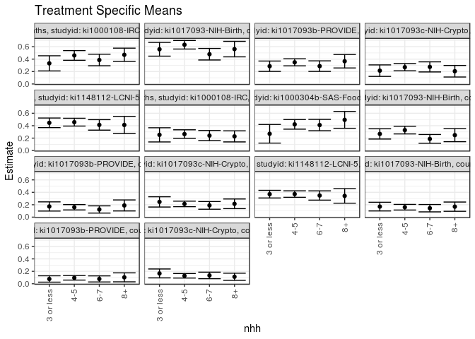

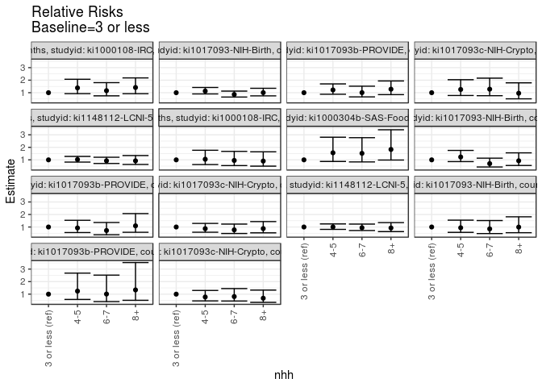

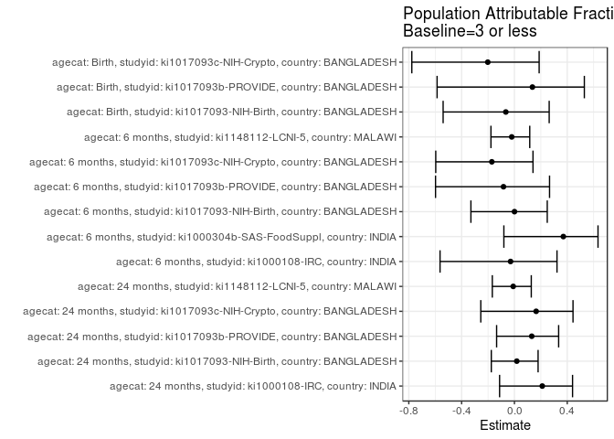

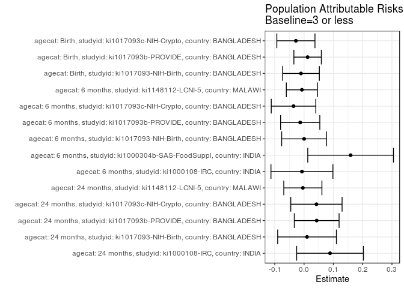

## Results Table

### Parameter: TSM

| agecat | studyid | country | intervention_level | baseline_level | estimate | ci_lower | ci_upper |
| --- | --- | --- | --- | --- | --- | --- | --- |
| Birth | ki1017093-NIH-Birth | BANGLADESH | 3 or less | NA | 0.1699443 | 0.1001855 | 0.2397031 |
| Birth | ki1017093-NIH-Birth | BANGLADESH | 4-5 | NA | 0.1598170 | 0.1147401 | 0.2048939 |
| Birth | ki1017093-NIH-Birth | BANGLADESH | 6-7 | NA | 0.1443118 | 0.0849843 | 0.2036392 |
| Birth | ki1017093-NIH-Birth | BANGLADESH | 8+ | NA | 0.1687289 | 0.0941404 | 0.2433174 |
| Birth | ki1017093b-PROVIDE | BANGLADESH | 3 or less | NA | 0.0769231 | 0.0256627 | 0.1281835 |
| Birth | ki1017093b-PROVIDE | BANGLADESH | 4-5 | NA | 0.0956175 | 0.0592043 | 0.1320308 |
| Birth | ki1017093b-PROVIDE | BANGLADESH | 6-7 | NA | 0.0775862 | 0.0288583 | 0.1263141 |
| Birth | ki1017093b-PROVIDE | BANGLADESH | 8+ | NA | 0.1029412 | 0.0306472 | 0.1752351 |
| Birth | ki1017093c-NIH-Crypto | BANGLADESH | 3 or less | NA | 0.1658396 | 0.0942313 | 0.2374479 |
| Birth | ki1017093c-NIH-Crypto | BANGLADESH | 4-5 | NA | 0.1282078 | 0.0916373 | 0.1647783 |
| Birth | ki1017093c-NIH-Crypto | BANGLADESH | 6-7 | NA | 0.1337151 | 0.0812283 | 0.1862019 |
| Birth | ki1017093c-NIH-Crypto | BANGLADESH | 8+ | NA | 0.1123030 | 0.0546592 | 0.1699468 |
| 6 months | ki1000108-IRC | INDIA | 3 or less | NA | 0.2528872 | 0.1389202 | 0.3668543 |
| 6 months | ki1000108-IRC | INDIA | 4-5 | NA | 0.2652671 | 0.1964001 | 0.3341341 |
| 6 months | ki1000108-IRC | INDIA | 6-7 | NA | 0.2409951 | 0.1590255 | 0.3229647 |
| 6 months | ki1000108-IRC | INDIA | 8+ | NA | 0.2284289 | 0.1391584 | 0.3176993 |
| 6 months | ki1000304b-SAS-FoodSuppl | INDIA | 3 or less | NA | 0.2700229 | 0.1198391 | 0.4202067 |
| 6 months | ki1000304b-SAS-FoodSuppl | INDIA | 4-5 | NA | 0.4220873 | 0.3446259 | 0.4995486 |
| 6 months | ki1000304b-SAS-FoodSuppl | INDIA | 6-7 | NA | 0.4106477 | 0.3189610 | 0.5023345 |
| 6 months | ki1000304b-SAS-FoodSuppl | INDIA | 8+ | NA | 0.4943206 | 0.3588329 | 0.6298084 |
| 6 months | ki1017093-NIH-Birth | BANGLADESH | 3 or less | NA | 0.2680383 | 0.1854720 | 0.3506046 |
| 6 months | ki1017093-NIH-Birth | BANGLADESH | 4-5 | NA | 0.3292793 | 0.2674858 | 0.3910728 |
| 6 months | ki1017093-NIH-Birth | BANGLADESH | 6-7 | NA | 0.1875809 | 0.1167445 | 0.2584174 |
| 6 months | ki1017093-NIH-Birth | BANGLADESH | 8+ | NA | 0.2482872 | 0.1431009 | 0.3534734 |
| 6 months | ki1017093b-PROVIDE | BANGLADESH | 3 or less | NA | 0.1721186 | 0.0980450 | 0.2461922 |
| 6 months | ki1017093b-PROVIDE | BANGLADESH | 4-5 | NA | 0.1592498 | 0.1164192 | 0.2020804 |
| 6 months | ki1017093b-PROVIDE | BANGLADESH | 6-7 | NA | 0.1238248 | 0.0656433 | 0.1820062 |
| 6 months | ki1017093b-PROVIDE | BANGLADESH | 8+ | NA | 0.1884200 | 0.0999902 | 0.2768498 |
| 6 months | ki1017093c-NIH-Crypto | BANGLADESH | 3 or less | NA | 0.2456964 | 0.1630746 | 0.3283183 |
| 6 months | ki1017093c-NIH-Crypto | BANGLADESH | 4-5 | NA | 0.2129596 | 0.1686246 | 0.2572946 |
| 6 months | ki1017093c-NIH-Crypto | BANGLADESH | 6-7 | NA | 0.1894501 | 0.1275260 | 0.2513742 |
| 6 months | ki1017093c-NIH-Crypto | BANGLADESH | 8+ | NA | 0.2146216 | 0.1366926 | 0.2925507 |
| 6 months | ki1148112-LCNI-5 | MALAWI | 3 or less | NA | 0.3701658 | 0.3085861 | 0.4317455 |
| 6 months | ki1148112-LCNI-5 | MALAWI | 4-5 | NA | 0.3716979 | 0.3196339 | 0.4237618 |
| 6 months | ki1148112-LCNI-5 | MALAWI | 6-7 | NA | 0.3486076 | 0.2742547 | 0.4229605 |
| 6 months | ki1148112-LCNI-5 | MALAWI | 8+ | NA | 0.3420032 | 0.2248996 | 0.4591068 |
| 24 months | ki1000108-IRC | INDIA | 3 or less | NA | 0.3318586 | 0.2100484 | 0.4536688 |
| 24 months | ki1000108-IRC | INDIA | 4-5 | NA | 0.4592373 | 0.3809416 | 0.5375329 |
| 24 months | ki1000108-IRC | INDIA | 6-7 | NA | 0.3858746 | 0.2928753 | 0.4788740 |
| 24 months | ki1000108-IRC | INDIA | 8+ | NA | 0.4697242 | 0.3628146 | 0.5766338 |
| 24 months | ki1017093-NIH-Birth | BANGLADESH | 3 or less | NA | 0.5586015 | 0.4476501 | 0.6695530 |
| 24 months | ki1017093-NIH-Birth | BANGLADESH | 4-5 | NA | 0.6315610 | 0.5624502 | 0.7006717 |
| 24 months | ki1017093-NIH-Birth | BANGLADESH | 6-7 | NA | 0.4791293 | 0.3861095 | 0.5721490 |
| 24 months | ki1017093-NIH-Birth | BANGLADESH | 8+ | NA | 0.5614493 | 0.4365746 | 0.6863239 |
| 24 months | ki1017093b-PROVIDE | BANGLADESH | 3 or less | NA | 0.2856085 | 0.2020700 | 0.3691469 |
| 24 months | ki1017093b-PROVIDE | BANGLADESH | 4-5 | NA | 0.3486938 | 0.2919439 | 0.4054437 |
| 24 months | ki1017093b-PROVIDE | BANGLADESH | 6-7 | NA | 0.2871826 | 0.2021031 | 0.3722621 |
| 24 months | ki1017093b-PROVIDE | BANGLADESH | 8+ | NA | 0.3659751 | 0.2573898 | 0.4745604 |
| 24 months | ki1017093c-NIH-Crypto | BANGLADESH | 3 or less | NA | 0.2145589 | 0.1220153 | 0.3071025 |
| 24 months | ki1017093c-NIH-Crypto | BANGLADESH | 4-5 | NA | 0.2699674 | 0.2121970 | 0.3277378 |
| 24 months | ki1017093c-NIH-Crypto | BANGLADESH | 6-7 | NA | 0.2748634 | 0.1934948 | 0.3562321 |
| 24 months | ki1017093c-NIH-Crypto | BANGLADESH | 8+ | NA | 0.2051595 | 0.1122247 | 0.2980943 |
| 24 months | ki1148112-LCNI-5 | MALAWI | 3 or less | NA | 0.4466164 | 0.3694231 | 0.5238097 |
| 24 months | ki1148112-LCNI-5 | MALAWI | 4-5 | NA | 0.4573277 | 0.3943933 | 0.5202620 |
| 24 months | ki1148112-LCNI-5 | MALAWI | 6-7 | NA | 0.4132400 | 0.3286862 | 0.4977937 |
| 24 months | ki1148112-LCNI-5 | MALAWI | 8+ | NA | 0.4121908 | 0.2741932 | 0.5501885 |

### Parameter: E(Y)

| agecat | studyid | country | intervention_level | baseline_level | estimate | ci_lower | ci_upper |
| --- | --- | --- | --- | --- | --- | --- | --- |
| Birth | ki1017093-NIH-Birth | BANGLADESH | NA | NA | 0.1595395 | 0.1304091 | 0.1886699 |
| Birth | ki1017093b-PROVIDE | BANGLADESH | NA | NA | 0.0890538 | 0.0649864 | 0.1131212 |
| Birth | ki1017093c-NIH-Crypto | BANGLADESH | NA | NA | 0.1379781 | 0.1129774 | 0.1629789 |
| 6 months | ki1000108-IRC | INDIA | NA | NA | 0.2457002 | 0.2038248 | 0.2875757 |
| 6 months | ki1000304b-SAS-FoodSuppl | INDIA | NA | NA | 0.4289474 | 0.3791199 | 0.4787748 |
| 6 months | ki1017093-NIH-Birth | BANGLADESH | NA | NA | 0.2681564 | 0.2306532 | 0.3056597 |
| 6 months | ki1017093b-PROVIDE | BANGLADESH | NA | NA | 0.1589404 | 0.1297581 | 0.1881227 |
| 6 months | ki1017093c-NIH-Crypto | BANGLADESH | NA | NA | 0.2097902 | 0.1799252 | 0.2396552 |
| 6 months | ki1148112-LCNI-5 | MALAWI | NA | NA | 0.3627451 | 0.3297365 | 0.3957537 |
| 24 months | ki1000108-IRC | INDIA | NA | NA | 0.4205379 | 0.3726382 | 0.4684376 |
| 24 months | ki1017093-NIH-Birth | BANGLADESH | NA | NA | 0.5687646 | 0.5218455 | 0.6156837 |
| 24 months | ki1017093b-PROVIDE | BANGLADESH | NA | NA | 0.3287197 | 0.2903909 | 0.3670485 |
| 24 months | ki1017093c-NIH-Crypto | BANGLADESH | NA | NA | 0.2568093 | 0.2190047 | 0.2946140 |
| 24 months | ki1148112-LCNI-5 | MALAWI | NA | NA | 0.4425087 | 0.4018409 | 0.4831765 |

### Parameter: RR

| agecat | studyid | country | intervention_level | baseline_level | estimate | ci_lower | ci_upper |
| --- | --- | --- | --- | --- | --- | --- | --- |
| Birth | ki1017093-NIH-Birth | BANGLADESH | 3 or less | 3 or less | 1.0000000 | 1.0000000 | 1.000000 |
| Birth | ki1017093-NIH-Birth | BANGLADESH | 4-5 | 3 or less | 0.9404082 | 0.5721189 | 1.545776 |
| Birth | ki1017093-NIH-Birth | BANGLADESH | 6-7 | 3 or less | 0.8491709 | 0.4755766 | 1.516246 |
| Birth | ki1017093-NIH-Birth | BANGLADESH | 8+ | 3 or less | 0.9928481 | 0.5433944 | 1.814055 |
| Birth | ki1017093b-PROVIDE | BANGLADESH | 3 or less | 3 or less | 1.0000000 | 1.0000000 | 1.000000 |
| Birth | ki1017093b-PROVIDE | BANGLADESH | 4-5 | 3 or less | 1.2430279 | 0.5769645 | 2.678013 |
| Birth | ki1017093b-PROVIDE | BANGLADESH | 6-7 | 3 or less | 1.0086207 | 0.4036851 | 2.520072 |
| Birth | ki1017093b-PROVIDE | BANGLADESH | 8+ | 3 or less | 1.3382353 | 0.5082528 | 3.523588 |
| Birth | ki1017093c-NIH-Crypto | BANGLADESH | 3 or less | 3 or less | 1.0000000 | 1.0000000 | 1.000000 |
| Birth | ki1017093c-NIH-Crypto | BANGLADESH | 4-5 | 3 or less | 0.7730832 | 0.4610639 | 1.296258 |
| Birth | ki1017093c-NIH-Crypto | BANGLADESH | 6-7 | 3 or less | 0.8062917 | 0.4498624 | 1.445123 |
| Birth | ki1017093c-NIH-Crypto | BANGLADESH | 8+ | 3 or less | 0.6771784 | 0.3460555 | 1.325136 |
| 6 months | ki1000108-IRC | INDIA | 3 or less | 3 or less | 1.0000000 | 1.0000000 | 1.000000 |
| 6 months | ki1000108-IRC | INDIA | 4-5 | 3 or less | 1.0489540 | 0.6234025 | 1.764999 |
| 6 months | ki1000108-IRC | INDIA | 6-7 | 3 or less | 0.9529744 | 0.5419960 | 1.675585 |
| 6 months | ki1000108-IRC | INDIA | 8+ | 3 or less | 0.9032834 | 0.4971391 | 1.641233 |
| 6 months | ki1000304b-SAS-FoodSuppl | INDIA | 3 or less | 3 or less | 1.0000000 | 1.0000000 | 1.000000 |
| 6 months | ki1000304b-SAS-FoodSuppl | INDIA | 4-5 | 3 or less | 1.5631535 | 0.8707432 | 2.806165 |
| 6 months | ki1000304b-SAS-FoodSuppl | INDIA | 6-7 | 3 or less | 1.5207885 | 0.8344628 | 2.771600 |
| 6 months | ki1000304b-SAS-FoodSuppl | INDIA | 8+ | 3 or less | 1.8306618 | 0.9849917 | 3.402387 |
| 6 months | ki1017093-NIH-Birth | BANGLADESH | 3 or less | 3 or less | 1.0000000 | 1.0000000 | 1.000000 |
| 6 months | ki1017093-NIH-Birth | BANGLADESH | 4-5 | 3 or less | 1.2284787 | 0.8601956 | 1.754438 |
| 6 months | ki1017093-NIH-Birth | BANGLADESH | 6-7 | 3 or less | 0.6998289 | 0.4318395 | 1.134126 |
| 6 months | ki1017093-NIH-Birth | BANGLADESH | 8+ | 3 or less | 0.9263123 | 0.5500547 | 1.559944 |
| 6 months | ki1017093b-PROVIDE | BANGLADESH | 3 or less | 3 or less | 1.0000000 | 1.0000000 | 1.000000 |
| 6 months | ki1017093b-PROVIDE | BANGLADESH | 4-5 | 3 or less | 0.9252326 | 0.5570824 | 1.536677 |
| 6 months | ki1017093b-PROVIDE | BANGLADESH | 6-7 | 3 or less | 0.7194152 | 0.3803327 | 1.360804 |
| 6 months | ki1017093b-PROVIDE | BANGLADESH | 8+ | 3 or less | 1.0947101 | 0.5787805 | 2.070543 |
| 6 months | ki1017093c-NIH-Crypto | BANGLADESH | 3 or less | 3 or less | 1.0000000 | 1.0000000 | 1.000000 |
| 6 months | ki1017093c-NIH-Crypto | BANGLADESH | 4-5 | 3 or less | 0.8667590 | 0.5840066 | 1.286409 |
| 6 months | ki1017093c-NIH-Crypto | BANGLADESH | 6-7 | 3 or less | 0.7710738 | 0.4824605 | 1.232339 |
| 6 months | ki1017093c-NIH-Crypto | BANGLADESH | 8+ | 3 or less | 0.8735236 | 0.5328942 | 1.431886 |
| 6 months | ki1148112-LCNI-5 | MALAWI | 3 or less | 3 or less | 1.0000000 | 1.0000000 | 1.000000 |
| 6 months | ki1148112-LCNI-5 | MALAWI | 4-5 | 3 or less | 1.0041389 | 0.8093844 | 1.245755 |
| 6 months | ki1148112-LCNI-5 | MALAWI | 6-7 | 3 or less | 0.9417608 | 0.7193826 | 1.232881 |
| 6 months | ki1148112-LCNI-5 | MALAWI | 8+ | 3 or less | 0.9239190 | 0.6322854 | 1.350065 |
| 24 months | ki1000108-IRC | INDIA | 3 or less | 3 or less | 1.0000000 | 1.0000000 | 1.000000 |
| 24 months | ki1000108-IRC | INDIA | 4-5 | 3 or less | 1.3838342 | 0.9230795 | 2.074575 |
| 24 months | ki1000108-IRC | INDIA | 6-7 | 3 or less | 1.1627683 | 0.7497967 | 1.803195 |
| 24 months | ki1000108-IRC | INDIA | 8+ | 3 or less | 1.4154348 | 0.9185782 | 2.181040 |
| 24 months | ki1017093-NIH-Birth | BANGLADESH | 3 or less | 3 or less | 1.0000000 | 1.0000000 | 1.000000 |
| 24 months | ki1017093-NIH-Birth | BANGLADESH | 4-5 | 3 or less | 1.1306109 | 0.9022415 | 1.416784 |
| 24 months | ki1017093-NIH-Birth | BANGLADESH | 6-7 | 3 or less | 0.8577300 | 0.6525210 | 1.127474 |
| 24 months | ki1017093-NIH-Birth | BANGLADESH | 8+ | 3 or less | 1.0050980 | 0.7466530 | 1.353001 |
| 24 months | ki1017093b-PROVIDE | BANGLADESH | 3 or less | 3 or less | 1.0000000 | 1.0000000 | 1.000000 |
| 24 months | ki1017093b-PROVIDE | BANGLADESH | 4-5 | 3 or less | 1.2208805 | 0.8755914 | 1.702334 |
| 24 months | ki1017093b-PROVIDE | BANGLADESH | 6-7 | 3 or less | 1.0055116 | 0.6649097 | 1.520588 |
| 24 months | ki1017093b-PROVIDE | BANGLADESH | 8+ | 3 or less | 1.2813875 | 0.8472314 | 1.938023 |
| 24 months | ki1017093c-NIH-Crypto | BANGLADESH | 3 or less | 3 or less | 1.0000000 | 1.0000000 | 1.000000 |
| 24 months | ki1017093c-NIH-Crypto | BANGLADESH | 4-5 | 3 or less | 1.2582438 | 0.7770031 | 2.037543 |
| 24 months | ki1017093c-NIH-Crypto | BANGLADESH | 6-7 | 3 or less | 1.2810629 | 0.7590671 | 2.162025 |
| 24 months | ki1017093c-NIH-Crypto | BANGLADESH | 8+ | 3 or less | 0.9561919 | 0.5114020 | 1.787836 |
| 24 months | ki1148112-LCNI-5 | MALAWI | 3 or less | 3 or less | 1.0000000 | 1.0000000 | 1.000000 |
| 24 months | ki1148112-LCNI-5 | MALAWI | 4-5 | 3 or less | 1.0239832 | 0.8224389 | 1.274917 |
| 24 months | ki1148112-LCNI-5 | MALAWI | 6-7 | 3 or less | 0.9252682 | 0.7088940 | 1.207686 |
| 24 months | ki1148112-LCNI-5 | MALAWI | 8+ | 3 or less | 0.9229192 | 0.6342969 | 1.342872 |

### Parameter: PAR

| agecat | studyid | country | intervention_level | baseline_level | estimate | ci_lower | ci_upper |
| --- | --- | --- | --- | --- | --- | --- | --- |
| Birth | ki1017093-NIH-Birth | BANGLADESH | 3 or less | NA | -0.0104048 | -0.0730736 | 0.0522639 |
| Birth | ki1017093b-PROVIDE | BANGLADESH | 3 or less | NA | 0.0121307 | -0.0346973 | 0.0589588 |
| Birth | ki1017093c-NIH-Crypto | BANGLADESH | 3 or less | NA | -0.0278614 | -0.0929441 | 0.0372212 |
| 6 months | ki1000108-IRC | INDIA | 3 or less | NA | -0.0071870 | -0.1129052 | 0.0985312 |
| 6 months | ki1000304b-SAS-FoodSuppl | INDIA | 3 or less | NA | 0.1589245 | 0.0126624 | 0.3051865 |
| 6 months | ki1017093-NIH-Birth | BANGLADESH | 3 or less | NA | 0.0001181 | -0.0763715 | 0.0766077 |
| 6 months | ki1017093b-PROVIDE | BANGLADESH | 3 or less | NA | -0.0131782 | -0.0801544 | 0.0537979 |
| 6 months | ki1017093c-NIH-Crypto | BANGLADESH | 3 or less | NA | -0.0359062 | -0.1119513 | 0.0401389 |
| 6 months | ki1148112-LCNI-5 | MALAWI | 3 or less | NA | -0.0074207 | -0.0605063 | 0.0456649 |
| 24 months | ki1000108-IRC | INDIA | 3 or less | NA | 0.0886793 | -0.0252134 | 0.2025721 |
| 24 months | ki1017093-NIH-Birth | BANGLADESH | 3 or less | NA | 0.0101630 | -0.0900683 | 0.1103944 |
| 24 months | ki1017093b-PROVIDE | BANGLADESH | 3 or less | NA | 0.0431113 | -0.0333132 | 0.1195358 |
| 24 months | ki1017093c-NIH-Crypto | BANGLADESH | 3 or less | NA | 0.0422504 | -0.0452807 | 0.1297816 |
| 24 months | ki1148112-LCNI-5 | MALAWI | 3 or less | NA | -0.0041077 | -0.0691792 | 0.0609638 |

### Parameter: PAF

| agecat | studyid | country | intervention_level | baseline_level | estimate | ci_lower | ci_upper |
| --- | --- | --- | --- | --- | --- | --- | --- |
| Birth | ki1017093-NIH-Birth | BANGLADESH | 3 or less | NA | -0.0652179 | -0.5400772 | 0.2632257 |
| Birth | ki1017093b-PROVIDE | BANGLADESH | 3 or less | NA | 0.1362179 | -0.5857997 | 0.5294996 |
| Birth | ki1017093c-NIH-Crypto | BANGLADESH | 3 or less | NA | -0.2019265 | -0.7772195 | 0.1871418 |
| 6 months | ki1000108-IRC | INDIA | 3 or less | NA | -0.0292511 | -0.5634149 | 0.3224077 |
| 6 months | ki1000304b-SAS-FoodSuppl | INDIA | 3 or less | NA | 0.3704987 | -0.0799954 | 0.6330801 |
| 6 months | ki1017093-NIH-Birth | BANGLADESH | 3 or less | NA | 0.0004405 | -0.3296594 | 0.2485902 |
| 6 months | ki1017093b-PROVIDE | BANGLADESH | 3 or less | NA | -0.0829131 | -0.5975940 | 0.2659582 |
| 6 months | ki1017093c-NIH-Crypto | BANGLADESH | 3 or less | NA | -0.1711531 | -0.5960024 | 0.1406031 |
| 6 months | ki1148112-LCNI-5 | MALAWI | 3 or less | NA | -0.0204570 | -0.1778995 | 0.1159411 |
| 24 months | ki1000108-IRC | INDIA | 3 or less | NA | 0.2108712 | -0.1124069 | 0.4402009 |
| 24 months | ki1017093-NIH-Birth | BANGLADESH | 3 or less | NA | 0.0178686 | -0.1751769 | 0.1792027 |
| 24 months | ki1017093b-PROVIDE | BANGLADESH | 3 or less | NA | 0.1311490 | -0.1349458 | 0.3348563 |
| 24 months | ki1017093c-NIH-Crypto | BANGLADESH | 3 or less | NA | 0.1645207 | -0.2547424 | 0.4436900 |
| 24 months | ki1148112-LCNI-5 | MALAWI | 3 or less | NA | -0.0092827 | -0.1675761 | 0.1275501 |